# 1. BD Discrete-Time Survival (First Onset): fallback_emo_ace

## Data Wrangling

First, we will read in necessary packages and use parameters to read in our pre-built analysis dataset; then filter it for complete cases (according to the necessary variables to be used in analyses) and print a brief table outlining the unique number of subjects and total observations we possess in our “complete” analysis ready dataset

Dataset size check

| Dataset | Rows | Unique_IDs |
| --- | --- | --- |
| BD person-period (model-ready) | 77336 | 8559 |

Event counts by outcome x wave x cluster

| outcome | end_wave | cluster | events | intervals |
| --- | --- | --- | --- | --- |
| any_bsd | ses-02A | C1 | 39 | 6457 |
| any_bsd | ses-02A | C2 | 53 | 1796 |
| any_bsd | ses-04A | C1 | 149 | 5571 |
| any_bsd | ses-04A | C2 | 56 | 1448 |
| any_bsd | ses-06A | C1 | 84 | 3021 |
| any_bsd | ses-06A | C2 | 36 | 798 |
| bd_nos | ses-02A | C1 | 22 | 6473 |
| bd_nos | ses-02A | C2 | 33 | 1835 |
| bd_nos | ses-04A | C1 | 62 | 5599 |
| bd_nos | ses-04A | C2 | 25 | 1500 |
| bd_nos | ses-06A | C1 | 35 | 3078 |
| bd_nos | ses-06A | C2 | 24 | 840 |
| bipolar_I | ses-02A | C1 | 18 | 6492 |
| bipolar_I | ses-02A | C2 | 31 | 1849 |
| bipolar_I | ses-04A | C1 | 63 | 5616 |
| bipolar_I | ses-04A | C2 | 29 | 1509 |
| bipolar_I | ses-06A | C1 | 39 | 3078 |
| bipolar_I | ses-06A | C2 | 17 | 838 |
| bipolar_II | ses-02A | C1 | 9 | 6502 |
| bipolar_II | ses-02A | C2 | 13 | 1883 |
| bipolar_II | ses-04A | C1 | 28 | 5635 |
| bipolar_II | ses-04A | C2 | 8 | 1549 |
| bipolar_II | ses-06A | C1 | 16 | 3100 |
| bipolar_II | ses-06A | C2 | 4 | 869 |

Missingness (post-filter) by outcome

| outcome | n | n_miss_cluster | n_miss_age_base_c | n_miss_age_within_base | n_miss_baseline_status | n_miss_sex | n_miss_site_factor | n_miss_end_wave | n_miss_participant_id | n_miss_family_id | p_n_miss_cluster | p_n_miss_age_base_c | p_n_miss_age_within_base | p_n_miss_baseline_status | p_n_miss_sex | p_n_miss_site_factor | p_n_miss_end_wave | p_n_miss_participant_id | p_n_miss_family_id |
| --- | --- | --- | --- | --- | --- | --- | --- | --- | --- | --- | --- | --- | --- | --- | --- | --- | --- | --- | --- |
| any_bsd | 19091 | 0 | 0 | 0 | 0 | 0 | 0 | 0 | 0 | 0 | 0 | 0 | 0 | 0 | 0 | 0 | 0 | 0 | 0 |
| bd_nos | 19325 | 0 | 0 | 0 | 0 | 0 | 0 | 0 | 0 | 0 | 0 | 0 | 0 | 0 | 0 | 0 | 0 | 0 | 0 |
| bipolar_I | 19382 | 0 | 0 | 0 | 0 | 0 | 0 | 0 | 0 | 0 | 0 | 0 | 0 | 0 | 0 | 0 | 0 | 0 | 0 |
| bipolar_II | 19538 | 0 | 0 | 0 | 0 | 0 | 0 | 0 | 0 | 0 | 0 | 0 | 0 | 0 | 0 | 0 | 0 | 0 | 0 |

Baseline_status QC by outcome

| outcome | baseline_status | n | events |
| --- | --- | --- | --- |
| any_bsd | 0 | 19091 | 417 |
| bd_nos | 0 | 19325 | 201 |
| bipolar_I | 0 | 19382 | 197 |
| bipolar_II | 0 | 19538 | 78 |

Baseline prevalence at baseline (participants) by outcome - risk cluster

| outcome | cluster | n_participants | n_baseline_positive | pct_baseline_positive |
| --- | --- | --- | --- | --- |
| any_bsd | C1 | 6568 | 0 | 0.00% |
| any_bsd | C2 | 1834 | 0 | 0.00% |
| bd_nos | C1 | 6586 | 0 | 0.00% |
| bd_nos | C2 | 1874 | 0 | 0.00% |
| bipolar_I | C1 | 6604 | 0 | 0.00% |
| bipolar_I | C2 | 1888 | 0 | 0.00% |
| bipolar_II | C1 | 6616 | 0 | 0.00% |
| bipolar_II | C2 | 1921 | 0 | 0.00% |

```
Risk-set conditioning: excluded participants baseline-positive (and baseline-unknown) for ANY BSD; rows dropped = 611 (IDs from 8559 to 8402). Models omit a baseline term because only baseline-negative youth remain.
```

```
Any post-onset rows remain? FALSE
```

Event counts by outcome x wave x cluster (model-ready risk set; use for Table 1)

| outcome | end_wave | cluster | events | intervals |
| --- | --- | --- | --- | --- |
| any_bsd | ses-02A | C1 | 39 | 6457 |
| any_bsd | ses-02A | C2 | 53 | 1796 |
| any_bsd | ses-04A | C1 | 149 | 5571 |
| any_bsd | ses-04A | C2 | 56 | 1448 |
| any_bsd | ses-06A | C1 | 84 | 3021 |
| any_bsd | ses-06A | C2 | 36 | 798 |
| bd_nos | ses-02A | C1 | 22 | 6457 |
| bd_nos | ses-02A | C2 | 29 | 1796 |
| bd_nos | ses-04A | C1 | 62 | 5584 |
| bd_nos | ses-04A | C2 | 25 | 1470 |
| bd_nos | ses-06A | C1 | 35 | 3072 |
| bd_nos | ses-06A | C2 | 23 | 826 |
| bipolar_I | ses-02A | C1 | 18 | 6457 |
| bipolar_I | ses-02A | C2 | 28 | 1796 |
| bipolar_I | ses-04A | C1 | 63 | 5586 |
| bipolar_I | ses-04A | C2 | 28 | 1467 |
| bipolar_I | ses-06A | C1 | 39 | 3060 |
| bipolar_I | ses-06A | C2 | 16 | 821 |
| bipolar_II | ses-02A | C1 | 9 | 6457 |
| bipolar_II | ses-02A | C2 | 12 | 1796 |
| bipolar_II | ses-04A | C1 | 27 | 5595 |
| bipolar_II | ses-04A | C2 | 7 | 1477 |
| bipolar_II | ses-06A | C1 | 16 | 3082 |
| bipolar_II | ses-06A | C2 | 4 | 835 |

## Analysis Overview

**Our Goal**

Estimate discrete-time hazards with a logit link for first-onset bipolar outcomes-BD-I, BD-II, BD-NOS, and Any BSD-from 02A onward, using the model-ready person-period datasets built previously

**Why discrete-time hazard (DTH)?**

- DTH models the probability of an onset within an interval, conditional on no prior onset. With assessments at distinct waves in ABCD, it is good practice here for us to:
  - Encode each interval as a row (person-period format)
  - Flexibly estimate the baseline hazard via wave fixed effects (i.e., dummies for 02A, 04A, 06A)
  - Include static and time-varying predictors alongside the hazard
  - This matches standard practice for event occurrence with panel waves (e.g., Singer & Willett)
- To note, intervals with missed waves contribute longer person-periods; our cloglog + offset(log interval) sensitivity shows results are robust to irregular interval length

**Why pooled logistic DTH (GLM) instead of a GLMM as primary?**

- ABCD follow-ups occur at distinct waves (02A, 04A, 06A), so event times are interval-censored by design; discrete-time hazard models on person-period data are therefore the natural framework (Singer & Willett)
- In our person-period data, clustering is extremely sparse (1–3 rows/person) with single-event censoring, and the participant random intercept is weakly identified. In mixed-effects fits, Laplace solutions with nAGQ ≥ 1 were unstable / optimizer-dependent and frequently produced degenerate Hessians when wave indicators and within-person age were both included
- We therefore use pooled logistic regression for primary inference and account for within-person dependence using participant-clustered robust SEs (CR2 primary; HC1 secondary). This yields stable, design-consistent inference without requiring estimation of a poorly-supported random effect structure
- Sensitivity analyses include: (i) complementary log-log with offset(log interval length), and (ii) mixed-effects versions only when estimable/stable (reported as diagnostics/sensitivity rather than primary inference)

**How we handle age (critical for interpretation)**

- Each youth’s current age decomposes into their age at baseline plus time since baseline:
  - `age_base_c`: between-person age = baseline age, grand-mean centered at the participant level (captures older vs younger youths)
  - Time since baseline: carried flexibly by the interval indicators (`end_wave`), which also set the baseline hazard
  - `age_within_base`: interval midpoint age minus baseline age (i.e., time since baseline at each interval midpoint)
- This preserves the within-between (Mundlak/hybrid) logic, but measures the between-person component at baseline. The person-mean of interval ages is not used: because the risk set ends at first onset, a person’s mean interval age partly reflects when (or whether) they had onset, so it carries outcome information. In a hazard model, covariates must be determined by information available at or before the time at risk (Kalbfleisch & Prentice, 2002); baseline age satisfies this by construction
  - Interpretation of `age_base_c`: difference in hazard for youths who were older vs younger at enrollment, at the same time since baseline
  - We originally interacted cluster x between-person age to ask whether cluster differences widen or narrow with age; it was unstable/non-significant and was dropped for parsimony and better diagnostics

> Within-person age is nearly collinear with the interval indicators given only three intervals (VIF ~15), so the primary model includes baseline age plus interval indicators; orthogonalized within-person age (`age_mid_cwc_orth`, i.e., `age_within_base` residualized on the interval indicators, capturing visit-timing variation within an interval) is included only as a sensitivity analysis

**Model we fit per outcome**

- Primary marginal DTH model (pooled logistic):
  - `event ~ cluster + sex + end_wave + age_base_c`
  - Inference: participant-clustered robust SEs (CR2 primary via `clubSandwich`; HC1 secondary via `sandwich`)
- Sensitivity models:
  - Linear time: replace `end_wave` with `wave_num` (1 df)
  - Within-person age robustness: include `age_mid_cwc_orth` (time since baseline at the interval midpoint, residualized on the interval indicators to avoid collinearity/identifiability issues)
  - Supplementary proportionality check: `event ~ cluster * end_wave + sex + age_base_c`, testing whether the cluster effect differs across intervals (joint CR2 Wald test) and reporting interval-specific cluster ORs
  - cloglog + offset(log_dt): event ~ … with binomial(link=“cloglog”) + offset(log_dt)
  - Mixed-effects diagnostics only: glmer(… + (1|participant_id)) at nAGQ=0 to compute ICC; nAGQ=1 and allFit() used to document optimizer dependence / instability (not used for primary inference)

## 1. Create Helper Functions to Use for Conducting Analyses

Multiple others for QC and plotting

## 2. Fit Discrete-Time Hazard Models

- Iterate over BD outcomes and fit pooled logistic DTH via `glm()` (primary logit link)
- Compute participant-clustered robust inference (CR2 primary; HC1 secondary)
- Fit sensitivity models: `wave_num`, `age_mid_cwc_orth`, and cloglog + offset(log_dt)
- Fit mixed-effects versions only as diagnostics/sensitivity: compute ICC from `glmer(..., nAGQ=0)` and document instability for `nAGQ=1` plus optimizer dependence via `allFit()`
- Persist all results (i.e., tables + model objects + diagnostic evidence) to `OUT_DIR`

```r
## 2. Fit models (primary GLM + sensitivities), summarize, and save ##

#2.0 Outcomes to iterate on for this analysis
OUTCOMES <- c("bipolar_I","bipolar_II","bd_nos","any_bsd")

#2.1 Preflight: fail-fast checks to avoid multi-hour jobs dying late
preflight_dth <- function(dat, outcomes = OUTCOMES) {

  #2.1.1 Minimal required columns
  req <- c("event","cluster","sex","end_wave","age_base_c","participant_id","family_id")
  miss <- setdiff(req, names(dat))
  if (length(miss) > 0) stop("Preflight failed: missing required columns: ", paste(miss, collapse = ", "))

  #2.1.2 Check factor levels exist (prevents empty levels() calls)
  if (nlevels(dat$end_wave) < 2) stop("Preflight failed: end_wave has <2 levels after filtering.")
  if (nlevels(dat$cluster) < 2)  stop("Preflight failed: cluster has <2 levels after filtering.")
  if (nlevels(dat$sex) < 1)      stop("Preflight failed: sex has 0 levels after filtering.")

  #2.1.3 Run one quick smoke test outcome to exercise:
  # - glm fit
  # - predict(newdata=...)
  # - cumrisk_by_wave_ci grid + bootMer path (with tiny B)
  out0 <- outcomes[1]
  dat0 <- dat %>% dplyr::filter(outcome == out0) %>% droplevels() %>% prep_dth_terms()

  #2.1.3.1 Ensure model can be fit
  fit0 <- fit_glm_safe(build_formula_primary(), dat0, link = "logit")

  #2.1.3.2 Ensure prediction helpers don't error (these are common late-fail points)
  invisible(pred_fixedwave_with_ci(fit0, dat0, ages = ages_pred_vec, wave_ref = params$wave_ref))
  invisible(hazard_by_wave_ci(fit0, dat0))
  invisible(cumrisk_by_wave_ci(fit0, dat0, B = 5))  # tiny B just to ensure code path works
  TRUE
}

message("Running preflight checks...")
```

```
Running preflight checks...
```

```r
preflight_dth(bd_pp_model)
```

[1] TRUE

```r
message("Preflight passed.")
```

```
Preflight passed.
```

```r
#2.2 Containers
fits_primary <- list()
fits_sens_cloglog <- list()
fits_sens_linT <- list()
fits_sens_within <- list()

tbl_cr2_primary <- list()
tbl_hc1_primary <- list()

tbl_cr2_cloglog <- list()
tbl_hc1_cloglog <- list()

tbl_cr2_linT <- list()
tbl_cr2_within <- list()

tbl_cr2_primary_fam <- list()

#2.3 Evidence objects supporting why GLMM is not primary for this analysis
vif_evidence <- list()
icc_evidence <- list()
allfit_evidence <- list()
or_compare <- list()

#2.3.1 Model decision log; seed with previously-attempted families so they appear in the HTML
model_log <- decision_log_init()

model_log <- add_decision(
  model_log,
  model_family = "DTH pooled logistic (primary)",
  engine = "glm + clubSandwich",
  specification = "event ~ cluster + sex + end_wave + age_base_c; CR2 clustered by participant (HC1 secondary)",
  status = "used_primary",
  key_diagnostics = "Stable fits across outcomes; design-consistent inference with clustered SEs",
  decision_rationale = "Primary model: avoids weakly-identified random intercept with 1–3 rows/person and sparse events")

model_log <- add_decision(
  model_log,
  model_family = "DTH cloglog + offset(log_dt)",
  engine = "glm + clubSandwich",
  specification = "event ~ cluster + sex + end_wave + age_base_c + offset(log_dt); CR2 clustered by participant",
  status = "sensitivity",
  key_diagnostics = "Robustness to unequal interval lengths (missed waves -> longer dt)",
  decision_rationale = "Sensitivity: approximates continuous-time proportional hazards under discrete intervals")

#2.3.2 Seed previously tried approaches even if not run in this script
model_log <- add_decision(
  model_log,
  model_family = "GLMM (random intercept)",
  engine = "lme4::glmer",
  specification = "event ~ cluster + sex + end_wave + age_base_c + (1|participant_id) [+ optional (1|family_id)/(1|site_factor)]",
  status = "diagnostic_only",
  key_diagnostics = "Often optimizer-dependent / degenerate Hessians when wave FE + within-age included; RE weakly identified",
  decision_rationale = "Documented as diagnostics; not used for primary inference")

model_log <- add_decision(
  model_log,
  model_family = "GAMM / spline time (previous)",
  engine = "mgcv (e.g., gam/bam)",
  specification = "event ~ cluster + sex + s(age_mid) + (random effects as applicable) + wave terms",
  status = "attempted_previous",
  key_diagnostics = "Issues with concurvity, unstable smooths with only 3 waves, separation in cells",
  decision_rationale = "Not carried forward: limited unique timepoints (3 waves) makes smooth terms poorly supported")

model_log <- add_decision(
  model_log,
  model_family = "glmmTMB (previous)",
  engine = "glmmTMB",
  specification = "Binomial mixed model variants (including alternative RE structures / dispersion handling)",
  status = "attempted_previous",
  key_diagnostics = "Issues with convergence warnings, boundary fits, separation, etc.",
  decision_rationale = "Not carried forward since convergence/identifiability issues persisted and estimates were optimizer-dependent")

model_log <- add_decision(
  model_log,
  model_family = "Bayesian (brms) (previous)",
  engine = "brms",
  specification = "Bernoulli/logit or cloglog with priors; random intercepts; optional varying effects",
  status = "attempted_previous",
  key_diagnostics = "Issues with divergent transitions, weak ID for RE, and especially sensitivity to priors (without justification for any specific prior distribution)",
  decision_rationale = "Not carried forward since computationally heavy without improving stability/interpretability given sparse intervals")

#2.4 Loop per outcome
for (out in OUTCOMES) {

  message("Primary GLM (logit): ", out)
  dat_o <- bd_pp_model %>% dplyr::filter(outcome == out) %>% droplevels() %>% prep_dth_terms()

  #2.4.0 Guard: ensure sex has at least 1 non-NA level and remains a factor
  if (!("sex" %in% names(dat_o))) stop("dat_o missing sex for outcome ", out)
  if (!is.factor(dat_o$sex)) dat_o$sex <- factor(dat_o$sex)
  if (nlevels(dat_o$sex) < 1) stop("sex has 0 levels for outcome ", out)

  #2.4.1 Primary pooled logistic DTH
  f_primary <- build_formula_primary()
  m_glm <- fit_glm_safe(f_primary, dat_o, link = "logit")
  fits_primary[[out]] <- m_glm

  #2.4.2 GLM diagnostics: separation, influence, binned residuals, check_model panels
  #2.4.2.1 Separation screen for the actual primary model too
  sep_primary <- sep_screen(f_primary, dat_o, family = binomial(link="logit"))
  write_if_any(sep_primary, file.path(OUT_DIR, glue("sep_primary_{out}.csv")))

  #2.4.2.2 Append outcome-specific diagnostic snapshot to the model decision log
  nevents <- sum(dat_o$event == 1L, na.rm = TRUE)
  nrows <- nrow(dat_o)
  sep_flag <- if ("separation" %in% names(sep_primary)) as.character(sep_primary$separation[1]) else NA_character_

  model_log <- add_decision(
    model_log,
    model_family = "DTH pooled logistic (primary)",
    engine = "glm + clubSandwich",
    specification = "event ~ cluster + sex + end_wave + age_base_c; CR2 clustered by participant",
    outcome = out,
    status = "used_primary",
    key_diagnostics = glue::glue("n_rows={nrows}; n_events={nevents}; separation={sep_flag}"),
    decision_rationale = "Primary inference run")

  #2.4.2.3 Sparse cell scan; helps interpret separation / instability
  sc <- sparse_cells(dat_o, vars = c("end_wave","cluster","sex"), y = "event", min_n = 5)
  write_if_any(sc, file.path(OUT_DIR, glue("sparse_cells_{out}.csv")))

  #2.4.2.4 Influence measures
  infl_tbl <- tibble(
    outcome = out,
    .row = seq_len(nrow(dat_o)),
    hat = hatvalues(m_glm),
    cooksD = cooks.distance(m_glm))
  write_if_any(infl_tbl, file.path(OUT_DIR, glue("influence_basic_{out}.csv")))

  #2.4.2.5 Top influential rows
  top_infl <- infl_tbl %>% arrange(desc(cooksD)) %>% slice(1:25)
  write_if_any(top_infl, file.path(OUT_DIR, glue("influence_top25_{out}.csv")))

  #2.4.2.6 Binned residual plot (arm::binnedplot if available; otherwise skip)
  if (requireNamespace("arm", quietly = TRUE)) {
    fn <- file.path(OUT_DIR, glue("binned_resid_{out}.png"))
    if (requireNamespace("ragg", quietly = TRUE)) ragg::agg_png(fn, width=1800, height=1200, res=144) else png(fn, width=1800, height=1200, res=144)
    arm::binnedplot(x = fitted(m_glm), y = residuals(m_glm, type = "response"),
                    xlab = "Fitted", ylab = "Response residual")
    dev.off()
  }

  #2.4.2.7 check_model panels to file
  save_check_model_plots(m_glm, tag = glue("glm_{out}"))

  #2.4.3 Participant-clustered inference (CR2 primary; HC1 secondary)
  tbl_cr2_primary[[out]] <- safe_or_null(
  tidy_glm_cr2(m_glm, cluster_var = dat_o$participant_id) %>%
    dplyr::mutate(outcome = out, model = "logit_primary", se_type = "CR2", .before = 1))

  tbl_hc1_primary[[out]] <- safe_or_null(
  tidy_glm_hc1(m_glm, cluster_var = dat_o$participant_id) %>%
    dplyr::mutate(outcome = out, model = "logit_primary", se_type = "HC1", .before = 1))

  tbl_cr2_primary_fam[[out]] <- tidy_glm_cr2(m_glm, cluster_var = dat_o$family_id) %>%
  mutate(outcome = out, model = "logit_primary", se_type = "CR2_family", .before = 1)

  #2.4.4 Sensitivity A: linear time (wave_num)
  m_linT <- fit_glm_safe(build_formula_lin_time(), dat_o, link = "logit")
  fits_sens_linT[[out]] <- m_linT
  tbl_cr2_linT[[out]] <- tidy_glm_cr2(m_linT, cluster_var = dat_o$participant_id) %>%
    dplyr::mutate(outcome = out, model = "logit_lin_time", se_type = "CR2", .before = 1)

  #2.4.5 Sensitivity B: orthogonalized within-person age
  m_within <- fit_glm_safe(build_formula_within_orth(), dat_o, link = "logit")
  fits_sens_within[[out]] <- m_within
  tbl_cr2_within[[out]] <- tidy_glm_cr2(m_within, cluster_var = dat_o$participant_id) %>%
    dplyr::mutate(outcome = out, model = "logit_within_orth", se_type = "CR2", .before = 1)

  #2.4.6 Sensitivity C: cloglog + offset(log_dt)
  f_cloglog <- update.formula(f_primary, . ~ . + offset(log_dt))
  sep_cloglog <- sep_screen(f_cloglog, dat_o, family = binomial(link="cloglog"))
  m_clog <- fit_glm_safe(f_cloglog, dat_o, link = "cloglog")
  fits_sens_cloglog[[out]] <- m_clog

  tbl_cr2_cloglog[[out]] <- tidy_glm_cr2(m_clog, cluster_var = dat_o$participant_id) %>%
    dplyr::mutate(outcome = out, model = "cloglog_offset", se_type = "CR2", .before = 1)

  tbl_hc1_cloglog[[out]] <- tidy_glm_hc1(m_clog, cluster_var = dat_o$participant_id) %>%
    dplyr::mutate(outcome = out, model = "cloglog_offset", se_type = "HC1", .before = 1)

  #2.4.7 Evidence supporting dropping raw age_mid_cwc from primary when using wave indicators, AKA VIF / collinearity
  vif_tbl <- safe_or_null({
    cc <- performance::check_collinearity(glm(event ~ cluster + sex + end_wave + age_base_c + age_within_base,
                                              data = dat_o, family = binomial()))
    tibble::as_tibble(cc) %>% dplyr::mutate(outcome = out, .before = 1)
  })
  vif_evidence[[out]] <- vif_tbl

  #2.4.8 Evidence: GLMM ICC + allFit optimizer dependence at nAGQ>=1 (diagnostic only)
  #2.4.8.1 ICC from nAGQ=0 participant-only RE
  glmm0 <- safe_or_null(
    lme4::glmer(event ~ cluster + sex + end_wave + age_base_c + (1|participant_id),
                data = dat_o, family = binomial(), nAGQ = 0,
                control = glmerControl(optimizer="bobyqa", optCtrl=list(maxfun=2e5)))
  )
  if (!is.null(glmm0)) {
    vc <- as.data.frame(VarCorr(glmm0))$vcov[1]
    icc <- vc / (vc + (pi^2 / 3))
    icc_evidence[[out]] <- tibble::tibble(outcome = out, vcov = vc, icc = icc)
  }

  #2.4.8.2 nAGQ=1 + allFit: store convergence/degeneracy across optimizers if it runs
  glmm1 <- safe_or_null(tryCatch(update(glmm0, nAGQ = 1), error = function(e) NULL))
  if (!is.null(glmm1)) {
    af <- safe_or_null(lme4::allFit(glmm1))
    if (!is.null(af)) {
      ss <- summary(af)
      allfit_evidence[[out]] <- tibble::tibble(
        outcome = out,
        n_ok = ss$OK,
        n_fail = ss$failed,
        n_warn = ss$warnings
      )
      saveRDS(af, file.path(OUT_DIR, glue::glue("allFit_nAGQ1_{out}.rds")))
    }
  }

  #2.4.9 Evidence of point-estimate stability in GLM vs glmer nAGQ=0
  if (!is.null(glmm0)) {
    or_compare[[out]] <- tibble::tibble(
      outcome = out,
      OR_glm = exp(coef(m_glm)[["clusterC2"]]),
      OR_glmer_nAGQ0 = exp(lme4::fixef(glmm0)[["clusterC2"]])
    )
    saveRDS(glmm0, file.path(OUT_DIR, glue::glue("glmer_nAGQ0_diag_{out}.rds")))
  }
}
```

```
Primary GLM (logit): bipolar_I
```

```
Primary GLM (logit): bipolar_II
```

bobyqa : [failed] Nelder_Mead : [OK] nlminbwrap : [OK] nmkbw : [failed] optimx.L-BFGS-B : [failed] nloptwrap.NLOPT_LN_NELDERMEAD : [failed] nloptwrap.NLOPT_LN_BOBYQA : [OK]

```
Primary GLM (logit): bd_nos
```

bobyqa : [failed] Nelder_Mead : [OK] nlminbwrap : [OK] nmkbw : [failed] optimx.L-BFGS-B : [failed] nloptwrap.NLOPT_LN_NELDERMEAD : [failed] nloptwrap.NLOPT_LN_BOBYQA : [OK]

```
Primary GLM (logit): any_bsd
```

```r
#2.5 Bind and save outputs
cr2_all <- bind_rows(compact(c(tbl_cr2_primary, tbl_cr2_primary_fam,
                               tbl_cr2_linT, tbl_cr2_within, tbl_cr2_cloglog)))
hc1_all <- dplyr::bind_rows(purrr::compact(c(tbl_hc1_primary, tbl_hc1_cloglog)))

vif_all <- dplyr::bind_rows(purrr::compact(vif_evidence))
icc_all <- dplyr::bind_rows(purrr::compact(icc_evidence))
allfit_all <- dplyr::bind_rows(purrr::compact(allfit_evidence))
or_compare_all <- dplyr::bind_rows(purrr::compact(or_compare))

readr::write_csv(cr2_all, file.path(OUT_DIR, "bd_dth_inference_CR2.csv"))
readr::write_csv(hc1_all, file.path(OUT_DIR, "bd_dth_inference_HC1_participant.csv"))
write_if_any(vif_all, file.path(OUT_DIR, "bd_dth_vif_evidence.csv"))
write_if_any(icc_all, file.path(OUT_DIR, "bd_dth_icc_evidence.csv"))
write_if_any(allfit_all, file.path(OUT_DIR, "bd_dth_allFit_nAGQ1_summary.csv"))
write_if_any(or_compare_all, file.path(OUT_DIR, "bd_dth_or_compare_glm_vs_glmer0.csv"))

#2.5.1 Persist and display the model decision log
readr::write_csv(model_log, file.path(OUT_DIR, "bd_dth_model_decision_log.csv"))

knitr::kable(
  model_log,
  caption = "Model decision log (primary + sensitivity + previously attempted strategies)") %>% kableExtra::kable_styling(bootstrap_options = c("striped","hover","condensed","responsive"))
```

Model decision log (primary + sensitivity + previously attempted strategies)

| model_family | engine | specification | outcome | status | key_diagnostics | decision_rationale | artifact |
| --- | --- | --- | --- | --- | --- | --- | --- |
| DTH pooled logistic (primary) | glm + clubSandwich | event ~ cluster + sex + end_wave + age_base_c; CR2 clustered by participant (HC1 secondary) | NA | used_primary | Stable fits across outcomes; design-consistent inference with clustered SEs | Primary model: avoids weakly-identified random intercept with 1–3 rows/person and sparse events | NA |
| DTH cloglog + offset(log_dt) | glm + clubSandwich | event ~ cluster + sex + end_wave + age_base_c + offset(log_dt); CR2 clustered by participant | NA | sensitivity | Robustness to unequal interval lengths (missed waves -> longer dt) | Sensitivity: approximates continuous-time proportional hazards under discrete intervals | NA |
| GLMM (random intercept) | lme4::glmer | event ~ cluster + sex + end_wave + age_base_c + (1&#124;participant_id) [+ optional (1&#124;family_id)/(1&#124;site_factor)] | NA | diagnostic_only | Often optimizer-dependent / degenerate Hessians when wave FE + within-age included; RE weakly identified | Documented as diagnostics; not used for primary inference | NA |
| GAMM / spline time (previous) | mgcv (e.g., gam/bam) | event ~ cluster + sex + s(age_mid) + (random effects as applicable) + wave terms | NA | attempted_previous | Issues with concurvity, unstable smooths with only 3 waves, separation in cells | Not carried forward: limited unique timepoints (3 waves) makes smooth terms poorly supported | NA |
| glmmTMB (previous) | glmmTMB | Binomial mixed model variants (including alternative RE structures / dispersion handling) | NA | attempted_previous | Issues with convergence warnings, boundary fits, separation, etc. | Not carried forward since convergence/identifiability issues persisted and estimates were optimizer-dependent | NA |
| Bayesian (brms) (previous) | brms | Bernoulli/logit or cloglog with priors; random intercepts; optional varying effects | NA | attempted_previous | Issues with divergent transitions, weak ID for RE, and especially sensitivity to priors (without justification for any specific prior distribution) | Not carried forward since computationally heavy without improving stability/interpretability given sparse intervals | NA |
| DTH pooled logistic (primary) | glm + clubSandwich | event ~ cluster + sex + end_wave + age_base_c; CR2 clustered by participant | bipolar_I | used_primary | n_rows=19187; n_events=192; separation=NA | Primary inference run | NA |
| DTH pooled logistic (primary) | glm + clubSandwich | event ~ cluster + sex + end_wave + age_base_c; CR2 clustered by participant | bipolar_II | used_primary | n_rows=19242; n_events=75; separation=NA | Primary inference run | NA |
| DTH pooled logistic (primary) | glm + clubSandwich | event ~ cluster + sex + end_wave + age_base_c; CR2 clustered by participant | bd_nos | used_primary | n_rows=19205; n_events=196; separation=NA | Primary inference run | NA |
| DTH pooled logistic (primary) | glm + clubSandwich | event ~ cluster + sex + end_wave + age_base_c; CR2 clustered by participant | any_bsd | used_primary | n_rows=19091; n_events=417; separation=NA | Primary inference run | NA |

```r
#2.6 Create pred objects for downstream utilization
#2.6.1 Wald tables for reference from model-based SE; not robust
wald_all <- bind_rows(lapply(fits_primary, tidy_wald), .id = "outcome") %>%
  mutate(model = "logit_primary", .before = 1)

#2.6.2 Predictions for plots using primary link
pred_all_fixedwave <- bind_rows(lapply(OUTCOMES, function(out) {
  fit <- fits_primary[[out]]
  dat <- bd_pp_model %>% filter(outcome == out) %>% droplevels() %>% prep_dth_terms()
  df  <- pred_fixedwave_with_ci(fit, dat, ages = ages_pred_vec, wave_ref = params$wave_ref)
  mutate(df, outcome = out, model = params$link_primary, pred_mode = "fixed_wave", .before = 1)
}))

pred_all_aligned <- bind_rows(lapply(OUTCOMES, function(out) {
  fit <- fits_primary[[out]]
  dat <- bd_pp_model %>% filter(outcome == out) %>% droplevels() %>% prep_dth_terms()
  df  <- pred_aligned_with_ci(fit, dat, ages = ages_pred_vec)
  mutate(df, outcome = out, model = params$link_primary, pred_mode = "wave_aligned", .before = 1)
}))

#2.6.3 Calibration deciles using primary link
cal_all <- bind_rows(lapply(OUTCOMES, function(out) {
  fit <- fits_primary[[out]]
  dat <- bd_pp_model %>% filter(outcome == out) %>% droplevels() %>% prep_dth_terms()
  df <- calibration_df(fit, dat)
  mutate(df, outcome = out, model = params$link_primary, .before = 1)
}))

#2.6.4 Hazard-by-wave tables
hazard_tables_all <- bind_rows(lapply(OUTCOMES, function(out) {
  fit <- fits_primary[[out]]
  dat <- bd_pp_model %>% filter(outcome == out) %>% droplevels() %>% prep_dth_terms()
  df  <- hazard_by_wave_ci(fit, dat)
  mutate(df, outcome = out, model = params$link_primary, .before = 1)
}))

#2.6.5 Cumulative risk tables
cumrisk_tables_all <- dplyr::bind_rows(lapply(OUTCOMES, function(out) {
  fit <- fits_primary[[out]]
  dat <- bd_pp_model %>% filter(outcome == out) %>% droplevels() %>% prep_dth_terms()
  df <- tryCatch(
    cumrisk_by_wave_ci(fit, dat, B = 500),
    error = function(e) {
      warning("cumrisk_by_wave_ci failed for ", out, ": ", conditionMessage(e))
      tidyr::crossing(
        end_wave = factor(levels(dat$end_wave), levels = levels(dat$end_wave)),
        cluster = factor(levels(dat$cluster), levels = levels(dat$cluster))) %>%
        dplyr::mutate(
          cumrisk = NA_real_,
          cumrisk_lo = NA_real_,
          cumrisk_hi = NA_real_)
    })

  dplyr::mutate(df, outcome = out, model = params$link_primary, .before = 1)
}))

#2.6.6 Cluster contrasts
emm_all <- bind_rows(lapply(OUTCOMES, function(out) {
  fit <- fits_primary[[out]]
  dat <- bd_pp_model %>% filter(outcome == out) %>% droplevels() %>% prep_dth_terms()
  df  <- cluster_contrasts_by_age(fit, dat, ages = ages_pred_vec, wave_ref = params$wave_ref)
  mutate(df, outcome = out, model = params$link_primary, .before = 1)
}))

emm_wave_primary_all <- bind_rows(lapply(OUTCOMES, function(out) {
  fit <- fits_primary[[out]]
  dat <- bd_pp_model %>% filter(outcome == out) %>% droplevels() %>% prep_dth_terms()
  df  <- cluster_contrasts_by_wave_aligned(fit, dat)
  mutate(df, outcome = out, model = params$link_primary, .before = 1)
}))

#2.6.7 Write all pred objects to disk for reference
write_csv(wald_all, file.path(OUT_DIR, "bd_dth_wald_reference.csv"))
write_csv(pred_all_fixedwave, file.path(OUT_DIR, "bd_dth_preds_fixedwave.csv"))
write_csv(pred_all_aligned, file.path(OUT_DIR, "bd_dth_preds_wave_aligned.csv"))
write_csv(cal_all, file.path(OUT_DIR, "bd_dth_calibration_deciles.csv"))
write_csv(hazard_tables_all, file.path(OUT_DIR, "bd_dth_hazard_by_wave.csv"))
write_csv(cumrisk_tables_all, file.path(OUT_DIR, "bd_dth_cumrisk_by_wave.csv"))
write_csv(emm_all, file.path(OUT_DIR, "bd_dth_emmeans_contrasts_by_age.csv"))
write_csv(emm_wave_primary_all, file.path(OUT_DIR, "bd_dth_emmeans_contrasts_by_wave.csv"))

#2.7 Save models
purrr::iwalk(fits_primary, ~ saveRDS(.x, file.path(OUT_DIR, glue::glue("glm_primary_{.y}.rds"))))
purrr::iwalk(fits_sens_linT, ~ saveRDS(.x, file.path(OUT_DIR, glue::glue("glm_linT_{.y}.rds"))))
purrr::iwalk(fits_sens_within, ~ saveRDS(.x, file.path(OUT_DIR, glue::glue("glm_withinOrth_{.y}.rds"))))
purrr::iwalk(fits_sens_cloglog, ~ saveRDS(.x, file.path(OUT_DIR, glue::glue("glm_cloglogOffset_{.y}.rds"))))

#2.8 Show key evidence tables in HTML
if (nrow(icc_all) > 0) {
  knitr::kable(icc_all, digits = 4, caption = "ICC evidence from participant-only glmer (nAGQ=0; diagnostic)") %>%
    kableExtra::kable_styling(bootstrap_options = c("striped","hover","condensed","responsive"))
}
```

ICC evidence from participant-only glmer (nAGQ=0; diagnostic)

| outcome | vcov | icc |
| --- | --- | --- |
| bipolar_I | 0.1936 | 0.0556 |
| bipolar_II | 0.2169 | 0.0619 |
| bd_nos | 0.0965 | 0.0285 |
| any_bsd | 0.1648 | 0.0477 |

```r
if (nrow(or_compare_all) > 0) {
  knitr::kable(or_compare_all, digits = 4, caption = "Point-estimate stability: OR(cluster) GLM vs glmer nAGQ=0") %>%
    kableExtra::kable_styling(bootstrap_options = c("striped","hover","condensed","responsive"))
}
```

Point-estimate stability: OR(cluster) GLM vs glmer nAGQ=0

| outcome | OR_glm | OR_glmer_nAGQ0 |
| --- | --- | --- |
| bipolar_I | 2.3577 | 2.3650 |
| bipolar_II | 1.8015 | 1.8057 |
| bd_nos | 2.5166 | 2.5195 |
| any_bsd | 2.1579 | 2.1687 |

```r
if (nrow(allfit_all) > 0) {
  knitr::kable(allfit_all, digits = 0, caption = "Optimizer dependence: allFit summary for nAGQ=1 fits (diagnostic)") %>%
    kableExtra::kable_styling(bootstrap_options = c("striped","hover","condensed","responsive"))
}
```

Optimizer dependence: allFit summary for nAGQ=1 fits (diagnostic)

| outcome |
| --- |
| bipolar_II |
| bd_nos |

## 3. Determine Marginal Effects: Hazard by Cluster Across Age

Generates visualizations of predicted first-onset hazard vs age for each outcome and cluster, pairing each empirical age with its corresponding wave (02A/04A/06A) and within-person age deviation at 0. These visualize risk separation and trajectories across the median ages in the data at each timepoint

## Supplementary: Cluster x Interval (Proportionality) Check

The primary model assumes the cluster effect on the odds of first onset is the same in every interval. This supplementary model relaxes that assumption by adding a cluster x interval interaction, tests it jointly (Wald chi-square on the participant-clustered CR2 covariance), and reports interval-specific cluster odds ratios. It is supplementary only; the primary model is unchanged.

```r
## 2.S Supplementary: does the cluster effect differ across intervals? ##

#2.S.1 Containers
int_or_rows <- list()
int_test_rows <- list()

#2.S.2 Fit the primary specification plus a cluster x interval interaction, per outcome
for (oc in OUTCOMES) {
  res <- try({

    #2.S.2.1 Outcome-specific model-ready data, prepared exactly as for the primary model
    dat_i <- bd_pp_model %>% dplyr::filter(outcome == oc) %>% droplevels() %>% prep_dth_terms()
    fit_i <- fit_glm_safe(stats::as.formula("event ~ cluster * end_wave + sex + age_base_c"), dat_i, link = "logit")

    #2.S.2.2 Participant-clustered CR2 covariance, aligned to the model frame as in tidy_glm_cr2()
    idx <- as.integer(rownames(model.frame(fit_i)))
    V <- clubSandwich::vcovCR(fit_i, cluster = dat_i$participant_id[idx], type = "CR2")

    #2.S.2.3 Joint Wald chi-square test that every cluster x interval term is zero, on the CR2 covariance
    #      (with ~8,400 participant clusters the small-sample HTZ correction is immaterial, and it scales quadratically in clusters)
    int_idx <- grep("^clusterC2:end_wave", names(coef(fit_i)))
    b_int <- coef(fit_i)[int_idx]
    V_int <- as.matrix(V)[int_idx, int_idx, drop = FALSE]
    chi2 <- as.numeric(t(b_int) %*% solve(V_int) %*% b_int)
    int_test_rows[[oc]] <- tibble::tibble(
      outcome = oc, n_interaction_terms = length(int_idx),
      chi_sq = chi2, df = length(int_idx), p.value = stats::pchisq(chi2, df = length(int_idx), lower.tail = FALSE))

    #2.S.2.4 Interval-specific cluster ORs (C2 vs C1) on the CR2 covariance
    em <- emmeans::emmeans(fit_i, ~ cluster | end_wave, vcov. = as.matrix(V))
    sm <- summary(emmeans::contrast(em, method = "revpairwise"), infer = c(TRUE, TRUE)) %>% tibble::as_tibble()
    ci <- emm_ci_cols(sm)
    int_or_rows[[oc]] <- sm %>%
      dplyr::transmute(outcome = oc, end_wave = as.character(end_wave), contrast,
                       OR = exp(estimate), CI_lo = exp(.data[[ci$lo]]), CI_hi = exp(.data[[ci$hi]]), p.value)
  }, silent = TRUE)

  #2.S.2.5 Report a failure for this outcome without stopping the report
  if (inherits(res, "try-error")) message("Cluster x interval model failed for ", oc, ": ", conditionMessage(attr(res, "condition")))
}

#2.S.3 Save and display
int_tests_tbl <- dplyr::bind_rows(int_test_rows)
int_or_tbl <- dplyr::bind_rows(int_or_rows)
readr::write_csv(int_tests_tbl, file.path(OUT_DIR, "bd_dth_cluster_by_interval_tests.csv"))
readr::write_csv(int_or_tbl, file.path(OUT_DIR, "bd_dth_cluster_by_interval_ORs.csv"))
knitr::kable(int_tests_tbl, digits = 3,
             caption = "Supplementary: joint Wald chi-square test of the cluster x interval interaction (CR2 covariance)") %>%
  kableExtra::kable_styling(bootstrap_options = c("striped","hover","condensed","responsive"))
```

Supplementary: joint Wald chi-square test of the cluster x interval interaction (CR2 covariance)

| outcome | n_interaction_terms | chi_sq | df | p.value |
| --- | --- | --- | --- | --- |
| bipolar_I | 2 | 12.306 | 2 | 0.002 |
| bipolar_II | 2 | 8.337 | 2 | 0.015 |
| bd_nos | 2 | 9.388 | 2 | 0.009 |
| any_bsd | 2 | 23.102 | 2 | 0.000 |

```r
knitr::kable(int_or_tbl, digits = 3,
             caption = "Supplementary: interval-specific cluster odds ratios of first onset (C2 vs C1; CR2)") %>%
  kableExtra::kable_styling(bootstrap_options = c("striped","hover","condensed","responsive"))
```

Supplementary: interval-specific cluster odds ratios of first onset (C2 vs C1; CR2)

| outcome | end_wave | contrast | OR | CI_lo | CI_hi | p.value |
| --- | --- | --- | --- | --- | --- | --- |
| bipolar_I | ses-02A | C2 - C1 | 5.894 | 3.252 | 10.682 | 0.000 |
| bipolar_I | ses-04A | C2 - C1 | 1.774 | 1.130 | 2.783 | 0.013 |
| bipolar_I | ses-06A | C2 - C1 | 1.604 | 0.887 | 2.897 | 0.118 |
| bipolar_II | ses-02A | C2 - C1 | 5.263 | 2.224 | 12.453 | 0.000 |
| bipolar_II | ses-04A | C2 - C1 | 1.075 | 0.468 | 2.469 | 0.865 |
| bipolar_II | ses-06A | C2 - C1 | 1.016 | 0.341 | 3.024 | 0.978 |
| bd_nos | ses-02A | C2 - C1 | 4.947 | 2.831 | 8.644 | 0.000 |
| bd_nos | ses-04A | C2 - C1 | 1.586 | 0.993 | 2.534 | 0.054 |
| bd_nos | ses-06A | C2 - C1 | 2.577 | 1.512 | 4.391 | 0.000 |
| any_bsd | ses-02A | C2 - C1 | 5.249 | 3.457 | 7.969 | 0.000 |
| any_bsd | ses-04A | C2 - C1 | 1.533 | 1.120 | 2.098 | 0.008 |
| any_bsd | ses-06A | C2 - C1 | 1.736 | 1.163 | 2.590 | 0.007 |

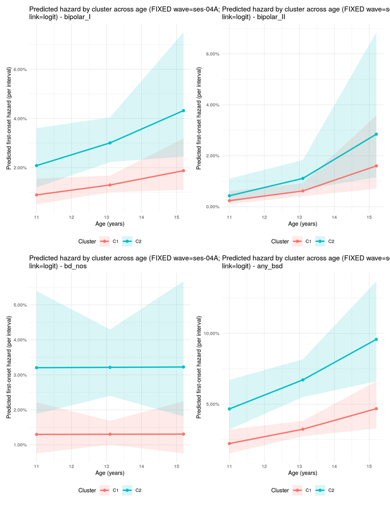

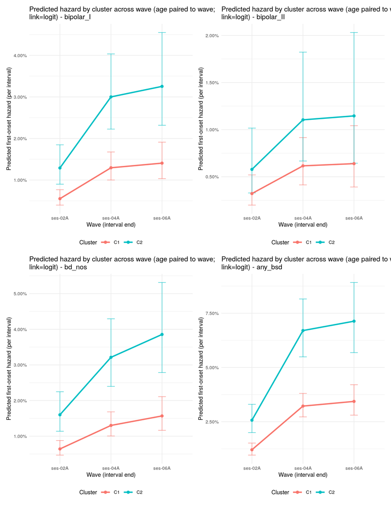

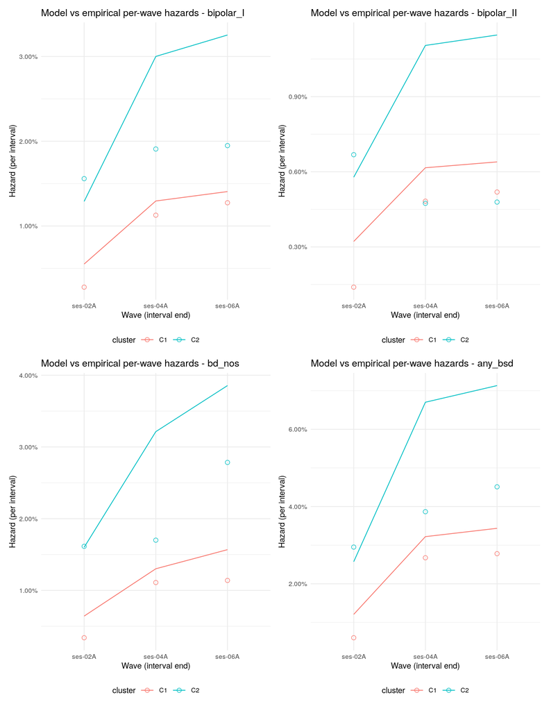

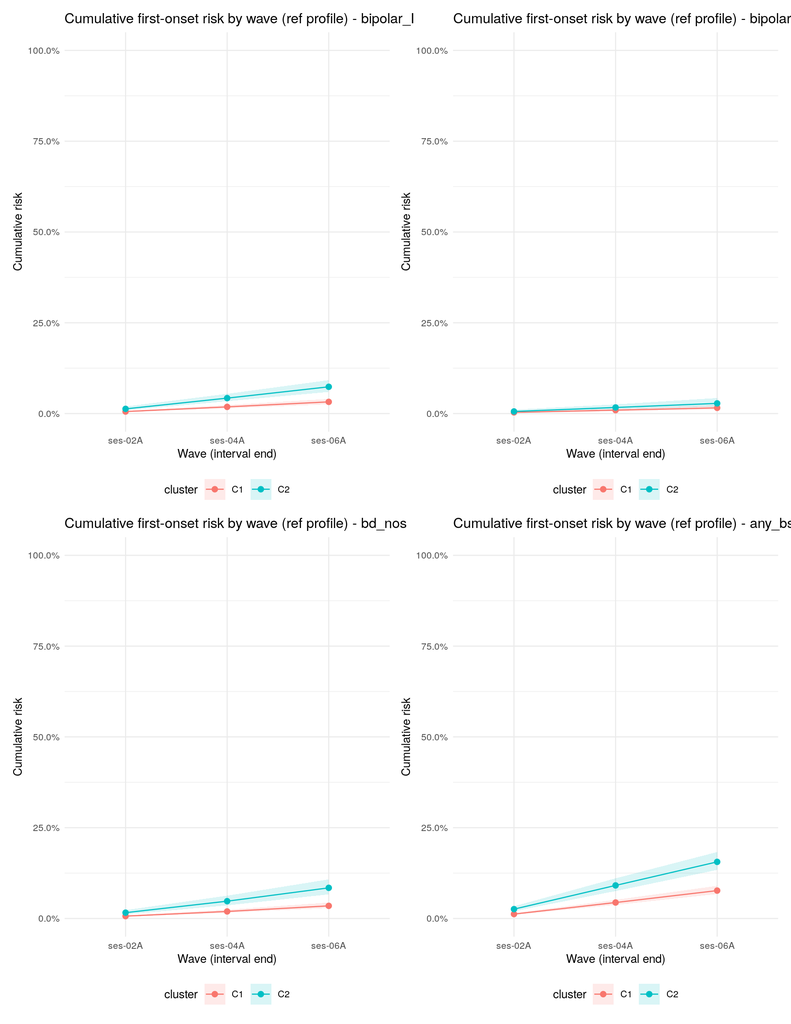

## 4. Baseline Hazard (Wave Effects) - Interpretability QC

Uses the fitted model to compute marginal baseline hazards by wave (sessions 02A, 04A, 06A) while holding other covariates at reference. Bar plots provide a quick sanity check that interval risks align with expected cohort timing

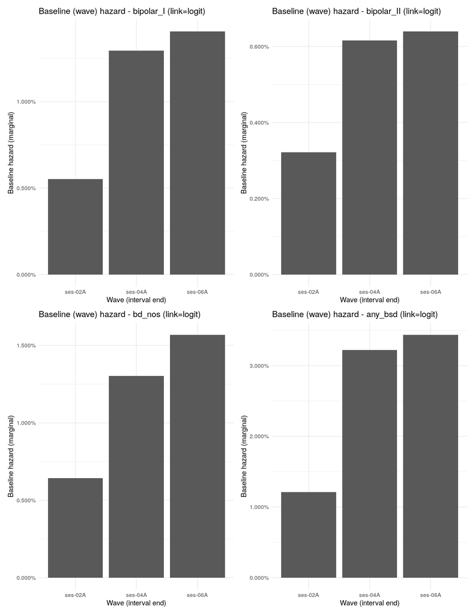

```r
## 4. Baseline hazard (wave FE -> marginal hazard by wave) ##

#4.1 Create a helper function to plot marginal hazard effects by assessment timepoint (wave)
plot_wave_hazard <- function(fit, data, title) {
  nd <- expand.grid(end_wave = levels(data$end_wave), cluster = levels(data$cluster)[1], age_base_c = 0, age_mid_cwc = 0, sex = levels(data$sex)[1])
  nd$pred <- predict(fit, newdata = nd, type = "response", re.form = NA)
  ggplot(nd, aes(x = end_wave, y = pred)) +
    geom_col() +
    scale_y_continuous(labels = scales::percent_format(accuracy = 0.001)) +
    labs(title = wrap_title(title, 70), x = "Wave (interval end)", y = "Baseline hazard (marginal)") +
    theme_minimal(base_size = 9) +
    theme(plot.title = element_text(lineheight = 0.95))
}

#4.2 Use the helper function to generate marginal hazard effects by wave plots
wave_plots <- lapply(OUTCOMES, function(out) {
  fit <- fits_primary[[out]]
  dat <- bd_pp_model %>% filter(outcome == out)
  plot_wave_hazard(fit, dat, glue("Baseline (wave) hazard - {out} (link={params$link_primary})"))
})

#4.3 Facet wrap the plots
wrap_plots(wave_plots, ncol = 2)
```

## 5. Perform Calibration (Using Decile Bins) for the Primary Link

Creates decile-bin calibration plots (mean predicted vs observed event rate). This checks probability calibration of the discrete-time models and helps flag miscalculation across the risk spectrum

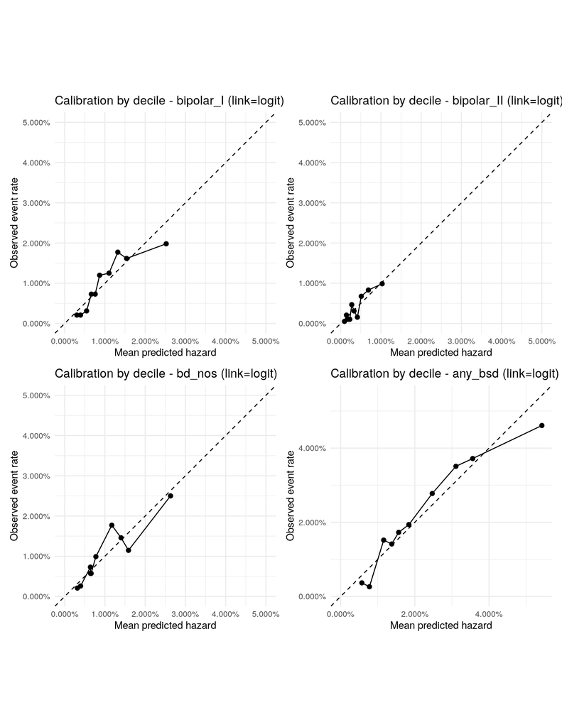

## 6. Generate Inference Tables (Wald vs CR2) Primary vs Sensitivity

We report participant-clustered robust inference as primary (CR2; HC1 secondary). Model-based (Wald) SEs from the pooled logistic model are shown only as a reference, since they assume independent rows and can be anti-conservative when within-person clustering is present

To note, odds ratios are per-interval hazard ratios on the logit scale; cluster main effects represent the average cluster gap across the modeled age range unless a cluster*x*age interaction is present (in which case interpret the interaction at the reported ages)

Fixed effects (Wald) Odds ratios with 95% CI (filtered)

| model | outcome | term | OR | CI_lo | CI_hi | p.value |
| --- | --- | --- | --- | --- | --- | --- |
| logit_primary | any_bsd | Cluster: C2 | 2.158 | 1.751 | 2.648 | 0.000 |
| logit_primary | any_bsd | Sex: Male | 0.507 | 0.414 | 0.619 | 0.000 |
| logit_primary | any_bsd | Baseline age (between-person) | 1.202 | 1.026 | 1.408 | 0.023 |
| logit_primary | bd_nos | Cluster: C2 | 2.517 | 1.876 | 3.358 | 0.000 |
| logit_primary | bd_nos | Sex: Male | 0.487 | 0.362 | 0.651 | 0.000 |
| logit_primary | bd_nos | Baseline age (between-person) | 1.002 | 0.796 | 1.259 | 0.989 |
| logit_primary | bipolar_I | Cluster: C2 | 2.358 | 1.746 | 3.161 | 0.000 |
| logit_primary | bipolar_I | Sex: Male | 0.590 | 0.440 | 0.786 | 0.000 |
| logit_primary | bipolar_I | Baseline age (between-person) | 1.196 | 0.949 | 1.508 | 0.129 |
| logit_primary | bipolar_II | Cluster: C2 | 1.801 | 1.079 | 2.917 | 0.020 |
| logit_primary | bipolar_II | Sex: Male | 0.350 | 0.209 | 0.568 | 0.000 |
| logit_primary | bipolar_II | Baseline age (between-person) | 1.579 | 1.090 | 2.303 | 0.016 |

Fixed effects (cluster-robust; see se_type for participant vs family; CR2 primary) Odds ratios with 95% CI (filtered)

| se_type | model | outcome | term | OR | CI_lo | CI_hi | p.value |
| --- | --- | --- | --- | --- | --- | --- | --- |
| CR2 | cloglog_offset | any_bsd | Cluster: C2 | 2.120 | 1.730 | 2.597 | 0.000 |
| CR2 | cloglog_offset | any_bsd | Sex: Male | 0.513 | 0.421 | 0.625 | 0.000 |
| CR2 | cloglog_offset | any_bsd | Baseline age (between-person) | 1.198 | 1.022 | 1.404 | 0.026 |
| CR2 | logit_lin_time | any_bsd | Cluster: C2 | 2.144 | 1.743 | 2.638 | 0.000 |
| CR2 | logit_lin_time | any_bsd | Sex: Male | 0.508 | 0.416 | 0.620 | 0.000 |
| CR2 | logit_lin_time | any_bsd | Baseline age (between-person) | 1.191 | 1.014 | 1.400 | 0.034 |
| CR2 | logit_primary | any_bsd | Cluster: C2 | 2.158 | 1.755 | 2.654 | 0.000 |
| CR2 | logit_primary | any_bsd | Sex: Male | 0.507 | 0.415 | 0.620 | 0.000 |
| CR2 | logit_primary | any_bsd | Baseline age (between-person) | 1.202 | 1.023 | 1.412 | 0.025 |
| CR2_family | logit_primary | any_bsd | Cluster: C2 | 2.158 | 1.752 | 2.657 | 0.000 |
| CR2_family | logit_primary | any_bsd | Sex: Male | 0.507 | 0.415 | 0.620 | 0.000 |
| CR2_family | logit_primary | any_bsd | Baseline age (between-person) | 1.202 | 1.022 | 1.414 | 0.027 |
| CR2 | logit_within_orth | any_bsd | Cluster: C2 | 2.158 | 1.755 | 2.653 | 0.000 |
| CR2 | logit_within_orth | any_bsd | Sex: Male | 0.505 | 0.414 | 0.617 | 0.000 |
| CR2 | logit_within_orth | any_bsd | Baseline age (between-person) | 1.184 | 1.007 | 1.391 | 0.041 |
| CR2 | cloglog_offset | bd_nos | Cluster: C2 | 2.496 | 1.872 | 3.328 | 0.000 |
| CR2 | cloglog_offset | bd_nos | Sex: Male | 0.490 | 0.366 | 0.655 | 0.000 |
| CR2 | cloglog_offset | bd_nos | Baseline age (between-person) | 1.001 | 0.797 | 1.257 | 0.994 |
| CR2 | logit_lin_time | bd_nos | Cluster: C2 | 2.509 | 1.876 | 3.357 | 0.000 |
| CR2 | logit_lin_time | bd_nos | Sex: Male | 0.488 | 0.364 | 0.653 | 0.000 |
| CR2 | logit_lin_time | bd_nos | Baseline age (between-person) | 0.996 | 0.792 | 1.254 | 0.975 |
| CR2 | logit_primary | bd_nos | Cluster: C2 | 2.517 | 1.882 | 3.364 | 0.000 |
| CR2 | logit_primary | bd_nos | Sex: Male | 0.487 | 0.364 | 0.653 | 0.000 |
| CR2 | logit_primary | bd_nos | Baseline age (between-person) | 1.002 | 0.796 | 1.260 | 0.989 |
| CR2_family | logit_primary | bd_nos | Cluster: C2 | 2.517 | 1.881 | 3.367 | 0.000 |
| CR2_family | logit_primary | bd_nos | Sex: Male | 0.487 | 0.364 | 0.653 | 0.000 |
| CR2_family | logit_primary | bd_nos | Baseline age (between-person) | 1.002 | 0.795 | 1.262 | 0.989 |
| CR2 | logit_within_orth | bd_nos | Cluster: C2 | 2.510 | 1.876 | 3.359 | 0.000 |
| CR2 | logit_within_orth | bd_nos | Sex: Male | 0.484 | 0.361 | 0.649 | 0.000 |
| CR2 | logit_within_orth | bd_nos | Baseline age (between-person) | 0.976 | 0.776 | 1.228 | 0.839 |
| CR2 | cloglog_offset | bipolar_I | Cluster: C2 | 2.338 | 1.741 | 3.139 | 0.000 |
| CR2 | cloglog_offset | bipolar_I | Sex: Male | 0.593 | 0.446 | 0.788 | 0.000 |
| CR2 | cloglog_offset | bipolar_I | Baseline age (between-person) | 1.195 | 0.941 | 1.518 | 0.144 |
| CR2 | logit_lin_time | bipolar_I | Cluster: C2 | 2.347 | 1.743 | 3.160 | 0.000 |
| CR2 | logit_lin_time | bipolar_I | Sex: Male | 0.590 | 0.443 | 0.786 | 0.000 |
| CR2 | logit_lin_time | bipolar_I | Baseline age (between-person) | 1.187 | 0.933 | 1.511 | 0.163 |
| CR2 | logit_primary | bipolar_I | Cluster: C2 | 2.358 | 1.752 | 3.173 | 0.000 |
| CR2 | logit_primary | bipolar_I | Sex: Male | 0.590 | 0.443 | 0.786 | 0.000 |
| CR2 | logit_primary | bipolar_I | Baseline age (between-person) | 1.196 | 0.940 | 1.522 | 0.146 |
| CR2_family | logit_primary | bipolar_I | Cluster: C2 | 2.358 | 1.746 | 3.184 | 0.000 |
| CR2_family | logit_primary | bipolar_I | Sex: Male | 0.590 | 0.442 | 0.788 | 0.000 |
| CR2_family | logit_primary | bipolar_I | Baseline age (between-person) | 1.196 | 0.938 | 1.524 | 0.148 |
| CR2 | logit_within_orth | bipolar_I | Cluster: C2 | 2.354 | 1.749 | 3.167 | 0.000 |
| CR2 | logit_within_orth | bipolar_I | Sex: Male | 0.588 | 0.441 | 0.783 | 0.000 |
| CR2 | logit_within_orth | bipolar_I | Baseline age (between-person) | 1.179 | 0.926 | 1.502 | 0.181 |
| CR2 | cloglog_offset | bipolar_II | Cluster: C2 | 1.795 | 1.110 | 2.901 | 0.017 |
| CR2 | cloglog_offset | bipolar_II | Sex: Male | 0.351 | 0.215 | 0.575 | 0.000 |
| CR2 | cloglog_offset | bipolar_II | Baseline age (between-person) | 1.577 | 1.068 | 2.329 | 0.022 |
| CR2 | logit_lin_time | bipolar_II | Cluster: C2 | 1.795 | 1.108 | 2.908 | 0.017 |
| CR2 | logit_lin_time | bipolar_II | Sex: Male | 0.351 | 0.214 | 0.574 | 0.000 |
| CR2 | logit_lin_time | bipolar_II | Baseline age (between-person) | 1.570 | 1.063 | 2.319 | 0.023 |
| CR2 | logit_primary | bipolar_II | Cluster: C2 | 1.801 | 1.113 | 2.916 | 0.017 |
| CR2 | logit_primary | bipolar_II | Sex: Male | 0.350 | 0.214 | 0.574 | 0.000 |
| CR2 | logit_primary | bipolar_II | Baseline age (between-person) | 1.579 | 1.068 | 2.334 | 0.022 |
| CR2_family | logit_primary | bipolar_II | Cluster: C2 | 1.801 | 1.113 | 2.915 | 0.017 |
| CR2_family | logit_primary | bipolar_II | Sex: Male | 0.350 | 0.214 | 0.574 | 0.000 |
| CR2_family | logit_primary | bipolar_II | Baseline age (between-person) | 1.579 | 1.068 | 2.334 | 0.022 |
| CR2 | logit_within_orth | bipolar_II | Cluster: C2 | 1.799 | 1.111 | 2.914 | 0.017 |
| CR2 | logit_within_orth | bipolar_II | Sex: Male | 0.351 | 0.214 | 0.574 | 0.000 |
| CR2 | logit_within_orth | bipolar_II | Baseline age (between-person) | 1.588 | 1.073 | 2.351 | 0.021 |

## 7. Cluster Contrasts at Representative Ages (Primary Link)

Cluster contrasts (OR) at ages 11, 13.1, 15.2 - primary link = logit

| outcome | model | age_years | contrast | OR | CI_lo | CI_hi | p.value |
| --- | --- | --- | --- | --- | --- | --- | --- |
| any_bsd | logit | 11.0 | C2 - C1 | 2.158 | 1.755 | 2.653 | 0.00 |
| any_bsd | logit | 13.1 | C2 - C1 | 2.158 | 1.755 | 2.653 | 0.00 |
| any_bsd | logit | 15.2 | C2 - C1 | 2.158 | 1.755 | 2.653 | 0.00 |
| bd_nos | logit | 11.0 | C2 - C1 | 2.517 | 1.882 | 3.365 | 0.00 |
| bd_nos | logit | 13.1 | C2 - C1 | 2.517 | 1.882 | 3.365 | 0.00 |
| bd_nos | logit | 15.2 | C2 - C1 | 2.517 | 1.882 | 3.365 | 0.00 |
| bipolar_I | logit | 11.0 | C2 - C1 | 2.358 | 1.753 | 3.170 | 0.00 |
| bipolar_I | logit | 13.1 | C2 - C1 | 2.358 | 1.753 | 3.170 | 0.00 |
| bipolar_I | logit | 15.2 | C2 - C1 | 2.358 | 1.753 | 3.170 | 0.00 |
| bipolar_II | logit | 11.0 | C2 - C1 | 1.801 | 1.098 | 2.955 | 0.02 |
| bipolar_II | logit | 13.1 | C2 - C1 | 1.801 | 1.098 | 2.955 | 0.02 |
| bipolar_II | logit | 15.2 | C2 - C1 | 1.801 | 1.098 | 2.955 | 0.02 |

Cluster contrasts (OR) by wave at each wave’s median age - primary link = logit

| outcome | model | end_wave | contrast | OR | CI_lo | CI_hi | p.value |
| --- | --- | --- | --- | --- | --- | --- | --- |
| any_bsd | logit | ses-02A | C2 - C1 | 2.158 | 1.755 | 2.653 | 0.00 |
| any_bsd | logit | ses-04A | C2 - C1 | 2.158 | 1.755 | 2.653 | 0.00 |
| any_bsd | logit | ses-06A | C2 - C1 | 2.158 | 1.755 | 2.653 | 0.00 |
| bd_nos | logit | ses-02A | C2 - C1 | 2.517 | 1.882 | 3.365 | 0.00 |
| bd_nos | logit | ses-04A | C2 - C1 | 2.517 | 1.882 | 3.365 | 0.00 |
| bd_nos | logit | ses-06A | C2 - C1 | 2.517 | 1.882 | 3.365 | 0.00 |
| bipolar_I | logit | ses-02A | C2 - C1 | 2.358 | 1.753 | 3.170 | 0.00 |
| bipolar_I | logit | ses-04A | C2 - C1 | 2.358 | 1.753 | 3.170 | 0.00 |
| bipolar_I | logit | ses-06A | C2 - C1 | 2.358 | 1.753 | 3.170 | 0.00 |
| bipolar_II | logit | ses-02A | C2 - C1 | 1.801 | 1.098 | 2.955 | 0.02 |
| bipolar_II | logit | ses-04A | C2 - C1 | 1.801 | 1.098 | 2.955 | 0.02 |
| bipolar_II | logit | ses-06A | C2 - C1 | 1.801 | 1.098 | 2.955 | 0.02 |

## Age Notes & Sensitivity

**Why decompose age?**

- In longitudinal hazards, naive “age” conflates two distinct things:
  - Aging within the same youth (time passing), carried here by the interval indicators
  - Older vs younger youths (between-person), carried here by baseline age (`age_base_c`)
- Between-person age is measured at baseline rather than as each person’s mean interval age, since the latter depends on how long each youth remained in the risk set and therefore on the outcome

## Final Story Template

In the interest of summarizing the many and complex analyses that were ran in service of answering the “when” of BD onset by risk cluster, the following is an attempt to summarize the most pertinent and meaningful analysis results.

Final story: key absolute risks & contrasts

| outcome | metric | end_wave | age_years | cluster | contrast | effect_scale | estimate | lo | hi | p.value |
| --- | --- | --- | --- | --- | --- | --- | --- | --- | --- | --- |
| any_bsd | OR | NA | 11.0 | NA | C2 - C1 | OR | 2.158 | 1.755 | 2.653 | 0.00 |
| any_bsd | OR | NA | 13.1 | NA | C2 - C1 | OR | 2.158 | 1.755 | 2.653 | 0.00 |
| any_bsd | OR | NA | 15.2 | NA | C2 - C1 | OR | 2.158 | 1.755 | 2.653 | 0.00 |
| any_bsd | cumulative_risk | ses-02A | NA | C1 | NA | NA | 0.012 | 0.010 | 0.015 | NA |
| any_bsd | cumulative_risk | ses-02A | NA | C2 | NA | NA | 0.026 | 0.020 | 0.034 | NA |
| any_bsd | cumulative_risk | ses-04A | NA | C1 | NA | NA | 0.044 | 0.037 | 0.051 | NA |
| any_bsd | cumulative_risk | ses-04A | NA | C2 | NA | NA | 0.091 | 0.075 | 0.110 | NA |
| any_bsd | cumulative_risk | ses-06A | NA | C1 | NA | NA | 0.077 | 0.067 | 0.090 | NA |
| any_bsd | cumulative_risk | ses-06A | NA | C2 | NA | NA | 0.156 | 0.134 | 0.183 | NA |
| any_bsd | hazard_per_interval | ses-02A | NA | C1 | NA | NA | 0.012 | 0.010 | 0.015 | NA |
| any_bsd | hazard_per_interval | ses-02A | NA | C2 | NA | NA | 0.026 | 0.020 | 0.033 | NA |
| any_bsd | hazard_per_interval | ses-04A | NA | C1 | NA | NA | 0.032 | 0.027 | 0.038 | NA |
| any_bsd | hazard_per_interval | ses-04A | NA | C2 | NA | NA | 0.067 | 0.055 | 0.082 | NA |
| any_bsd | hazard_per_interval | ses-06A | NA | C1 | NA | NA | 0.034 | 0.028 | 0.042 | NA |
| any_bsd | hazard_per_interval | ses-06A | NA | C2 | NA | NA | 0.071 | 0.057 | 0.089 | NA |
| bd_nos | OR | NA | 11.0 | NA | C2 - C1 | OR | 2.517 | 1.882 | 3.365 | 0.00 |
| bd_nos | OR | NA | 13.1 | NA | C2 - C1 | OR | 2.517 | 1.882 | 3.365 | 0.00 |
| bd_nos | OR | NA | 15.2 | NA | C2 - C1 | OR | 2.517 | 1.882 | 3.365 | 0.00 |
| bd_nos | cumulative_risk | ses-02A | NA | C1 | NA | NA | 0.006 | 0.005 | 0.009 | NA |
| bd_nos | cumulative_risk | ses-02A | NA | C2 | NA | NA | 0.016 | 0.011 | 0.023 | NA |
| bd_nos | cumulative_risk | ses-04A | NA | C1 | NA | NA | 0.019 | 0.016 | 0.024 | NA |
| bd_nos | cumulative_risk | ses-04A | NA | C2 | NA | NA | 0.048 | 0.036 | 0.063 | NA |
| bd_nos | cumulative_risk | ses-06A | NA | C1 | NA | NA | 0.035 | 0.029 | 0.044 | NA |
| bd_nos | cumulative_risk | ses-06A | NA | C2 | NA | NA | 0.084 | 0.066 | 0.108 | NA |
| bd_nos | hazard_per_interval | ses-02A | NA | C1 | NA | NA | 0.006 | 0.005 | 0.009 | NA |
| bd_nos | hazard_per_interval | ses-02A | NA | C2 | NA | NA | 0.016 | 0.011 | 0.022 | NA |
| bd_nos | hazard_per_interval | ses-04A | NA | C1 | NA | NA | 0.013 | 0.010 | 0.017 | NA |
| bd_nos | hazard_per_interval | ses-04A | NA | C2 | NA | NA | 0.032 | 0.024 | 0.043 | NA |
| bd_nos | hazard_per_interval | ses-06A | NA | C1 | NA | NA | 0.016 | 0.012 | 0.021 | NA |
| bd_nos | hazard_per_interval | ses-06A | NA | C2 | NA | NA | 0.039 | 0.028 | 0.053 | NA |
| bipolar_I | OR | NA | 11.0 | NA | C2 - C1 | OR | 2.358 | 1.753 | 3.170 | 0.00 |
| bipolar_I | OR | NA | 13.1 | NA | C2 - C1 | OR | 2.358 | 1.753 | 3.170 | 0.00 |
| bipolar_I | OR | NA | 15.2 | NA | C2 - C1 | OR | 2.358 | 1.753 | 3.170 | 0.00 |
| bipolar_I | cumulative_risk | ses-02A | NA | C1 | NA | NA | 0.006 | 0.004 | 0.007 | NA |
| bipolar_I | cumulative_risk | ses-02A | NA | C2 | NA | NA | 0.013 | 0.009 | 0.019 | NA |
| bipolar_I | cumulative_risk | ses-04A | NA | C1 | NA | NA | 0.018 | 0.014 | 0.023 | NA |
| bipolar_I | cumulative_risk | ses-04A | NA | C2 | NA | NA | 0.043 | 0.034 | 0.054 | NA |
| bipolar_I | cumulative_risk | ses-06A | NA | C1 | NA | NA | 0.032 | 0.026 | 0.040 | NA |
| bipolar_I | cumulative_risk | ses-06A | NA | C2 | NA | NA | 0.074 | 0.060 | 0.092 | NA |
| bipolar_I | hazard_per_interval | ses-02A | NA | C1 | NA | NA | 0.006 | 0.004 | 0.008 | NA |
| bipolar_I | hazard_per_interval | ses-02A | NA | C2 | NA | NA | 0.013 | 0.009 | 0.018 | NA |
| bipolar_I | hazard_per_interval | ses-04A | NA | C1 | NA | NA | 0.013 | 0.010 | 0.017 | NA |
| bipolar_I | hazard_per_interval | ses-04A | NA | C2 | NA | NA | 0.030 | 0.022 | 0.040 | NA |
| bipolar_I | hazard_per_interval | ses-06A | NA | C1 | NA | NA | 0.014 | 0.010 | 0.019 | NA |
| bipolar_I | hazard_per_interval | ses-06A | NA | C2 | NA | NA | 0.033 | 0.023 | 0.046 | NA |
| bipolar_II | OR | NA | 11.0 | NA | C2 - C1 | OR | 1.801 | 1.098 | 2.955 | 0.02 |
| bipolar_II | OR | NA | 13.1 | NA | C2 - C1 | OR | 1.801 | 1.098 | 2.955 | 0.02 |
| bipolar_II | OR | NA | 15.2 | NA | C2 - C1 | OR | 1.801 | 1.098 | 2.955 | 0.02 |
| bipolar_II | cumulative_risk | ses-02A | NA | C1 | NA | NA | 0.003 | 0.002 | 0.005 | NA |
| bipolar_II | cumulative_risk | ses-02A | NA | C2 | NA | NA | 0.006 | 0.003 | 0.011 | NA |
| bipolar_II | cumulative_risk | ses-04A | NA | C1 | NA | NA | 0.009 | 0.007 | 0.013 | NA |
| bipolar_II | cumulative_risk | ses-04A | NA | C2 | NA | NA | 0.017 | 0.011 | 0.025 | NA |
| bipolar_II | cumulative_risk | ses-06A | NA | C1 | NA | NA | 0.016 | 0.011 | 0.023 | NA |
| bipolar_II | cumulative_risk | ses-06A | NA | C2 | NA | NA | 0.028 | 0.020 | 0.043 | NA |
| bipolar_II | hazard_per_interval | ses-02A | NA | C1 | NA | NA | 0.003 | 0.002 | 0.005 | NA |
| bipolar_II | hazard_per_interval | ses-02A | NA | C2 | NA | NA | 0.006 | 0.003 | 0.010 | NA |
| bipolar_II | hazard_per_interval | ses-04A | NA | C1 | NA | NA | 0.006 | 0.004 | 0.009 | NA |
| bipolar_II | hazard_per_interval | ses-04A | NA | C2 | NA | NA | 0.011 | 0.007 | 0.018 | NA |
| bipolar_II | hazard_per_interval | ses-06A | NA | C1 | NA | NA | 0.006 | 0.004 | 0.010 | NA |
| bipolar_II | hazard_per_interval | ses-06A | NA | C2 | NA | NA | 0.011 | 0.006 | 0.020 | NA |

## Cumulative Risk Contrasts (RD and RR)

Cluster risk differences and risk ratios of cumulative first-onset risk at each wave, with 95% simulation intervals from joint draws of the primary model’s coefficients under the participant-clustered CR2 covariance (B = 500).

Cumulative first-onset risk by cluster, with RD and RR (C2 vs C1) and 95% CR2 simulation intervals

| outcome | end_wave | cumrisk_C1 | cumrisk_C2 | RD | RD_lo | RD_hi | RR | RR_lo | RR_hi | B |
| --- | --- | --- | --- | --- | --- | --- | --- | --- | --- | --- |
| any_bsd | ses-02A | 0.012 | 0.026 | 0.014 | 0.009 | 0.020 | 2.128 | 1.762 | 2.570 | 500 |
| any_bsd | ses-04A | 0.044 | 0.091 | 0.047 | 0.033 | 0.065 | 2.073 | 1.732 | 2.478 | 500 |
| any_bsd | ses-06A | 0.077 | 0.156 | 0.079 | 0.056 | 0.106 | 2.030 | 1.707 | 2.414 | 500 |
| bd_nos | ses-02A | 0.006 | 0.016 | 0.010 | 0.005 | 0.016 | 2.492 | 1.894 | 3.328 | 500 |
| bd_nos | ses-04A | 0.019 | 0.048 | 0.028 | 0.018 | 0.043 | 2.460 | 1.877 | 3.274 | 500 |
| bd_nos | ses-06A | 0.035 | 0.084 | 0.050 | 0.032 | 0.072 | 2.428 | 1.859 | 3.219 | 500 |
| bipolar_I | ses-02A | 0.006 | 0.013 | 0.007 | 0.004 | 0.012 | 2.340 | 1.732 | 3.037 | 500 |
| bipolar_I | ses-04A | 0.018 | 0.043 | 0.024 | 0.015 | 0.035 | 2.312 | 1.719 | 2.992 | 500 |
| bipolar_I | ses-06A | 0.032 | 0.074 | 0.041 | 0.027 | 0.060 | 2.288 | 1.707 | 2.953 | 500 |
| bipolar_II | ses-02A | 0.003 | 0.006 | 0.003 | 0.001 | 0.006 | 1.797 | 1.165 | 2.860 | 500 |
| bipolar_II | ses-04A | 0.009 | 0.017 | 0.007 | 0.002 | 0.016 | 1.791 | 1.164 | 2.843 | 500 |
| bipolar_II | ses-06A | 0.016 | 0.028 | 0.012 | 0.003 | 0.026 | 1.786 | 1.163 | 2.827 | 500 |